# Enhanced Spotify Attribute Analysis

Corrected re-analysis (v2)

Lakshmi Sindhu Pulugundla

October 2026

# 0. What this document is

This is the same question as before — **which musical attributes predict how long a track gets listened to?** — asked of the same data, but with the data-quality problems of the first version fixed and every claim re-derived from scratch.

The first version (preserved, unchanged, in `../work/v1/`, alongside this repository) concluded that the three continuous attributes (danceability, energy, tempo) were *“redundant”* given genre and artist, and that the model *“does not predict playback time out of sample”*. Neither conclusion holds up as stated. One is reversed here; the other is true only on the untransformed scale. This version supersedes both, and Section 7 states exactly what changed.

Everything below is computed from the raw CSV in this document; there are no saved intermediate objects.

```r
have_nlme <- has("nlme")   # ships with R; used only for the mixed-model check
```

# 1. Data and the unit of observation

The file has 10080 rows and 22 columns. Before anything else: what is a row?

```r
raw <- read.csv("data/Spotify_Song_Attributes.csv", stringsAsFactors = FALSE)
pair <- paste(raw$trackName, raw$artistName)
cat("rows                        :", nrow(raw), "\n")
```

```
## rows                        : 10080
```

```r
cat("distinct (track, artist)    :", length(unique(pair)), "\n")
```

```
## distinct (track, artist)    : 5040
```

```r
cat("copies per track            :", paste(names(table(table(pair))), table(table(pair)), sep = "x", collapse = ", "), "\n")
```

```
## copies per track            : 2x5040
```

```r
cat("any timestamp / user / session column:",
    any(tolower(names(raw)) %in% c("ts", "user", "date", "endtime", "played_at")), "\n")
```

```
## any timestamp / user / session column: FALSE
```

Every track appears **exactly twice**, and the two copies are identical in every column that is not part of the key — not merely similar. The file cannot tell us which step produced it, but the pattern is what a join on a non-unique key leaves behind, and two further facts point the same way.

```r
same <- sapply(split(seq_len(nrow(raw)), pair),
               function(i) all(sapply(raw[i, -1], function(v) length(unique(v)) == 1)))
id_count <- table(raw$id[raw$id != ""])
cat("identical within pair, non-key columns :", all(same), "\n")
```

```
## identical within pair, non-key columns : TRUE
```

```r
cat("ids shared by two DIFFERENT titles    :",
    sum(sapply(names(id_count[id_count == 4]), function(i) length(unique(raw$trackName[raw$id == i])) == 2)), "\n")
```

```
## ids shared by two DIFFERENT titles    : 29
```

```r
cat("rows with a blank id (failed join)    :", sum(raw$id == ""), "\n")
```

```
## rows with a blank id (failed join)    : 550
```

The 29 ids that appear four times are each shared by **two different titles** (usually a track and another version of the same song). That is the signature of a join on `id` rather than on `id` plus a title key — and it has a consequence the first version never drew: those 58 tracks were given audio features looked up under an id that also belongs to another recording, so some of their features may describe the other version. The 550 blank-id rows carry no audio features at all, which is what the unmatched arm of such a join looks like: their metadata came through, their audio lookup did not.

**The unit of observation is one track, not one row.** All analysis below uses 5040 distinct tracks. Nothing about the coefficients of an ordinary least-squares fit changes when you duplicate rows, which is why the first version’s estimates looked plausible. The first version did notice the duplication and said so in its closing section, but its models were fitted before that point and were never re-fitted; the effect is that everything about its *inference* changes, because standard errors, p-values, AIC and every count were computed on twice as much data as existed.

```r
d <- raw[!duplicated(pair), ]
stopifnot(nrow(d) == length(unique(pair)))
d$artist_full <- trimws(d$artistName)   # kept uncut, for the dependence check in 5.3
```

## 1.1 What the response actually measures

`msPlayed` is cumulative time, not the length of one play. Comparing it to the track’s own duration (which the file provides) tells us whether a track was skipped, played once, or repeated.

```r
audio_vars <- c("danceability", "energy", "key", "loudness", "mode", "speechiness",
                "acousticness", "instrumentalness", "liveness", "valence", "tempo",
                "duration_ms", "time_signature")
d$audio_missing <- apply(d[, audio_vars], 1, function(r) all(is.na(r) | r == ""))
d$plays <- d$msPlayed / d$duration_ms

skip_share <- mean(d$plays < 1, na.rm = TRUE)
cat("tracks with no audio features at all :", sum(d$audio_missing), "\n")
```

```
## tracks with no audio features at all : 275
```

```r
cat("share of tracks below one full play  :", sprintf("%.1f%%", 100 * skip_share), "\n")
```

```
## share of tracks below one full play  : 37.5%
```

```r
cat("share below half a play              :", sprintf("%.1f%%", 100 * mean(d$plays < 0.5, na.rm = TRUE)), "\n")
```

```
## share below half a play              : 17.4%
```

```r
cat("median plays (tracks that were started):", sprintf("%.2f", median(d$plays, na.rm = TRUE)), "\n")
```

```
## median plays (tracks that were started): 1.15
```

```r
cat("maximum plays                        :", sprintf("%.0f", max(d$plays, na.rm = TRUE)), "\n")
```

```
## maximum plays                        : 651
```

```r
cat("maximum msPlayed                     :", sprintf("%.1f hours", max(d$msPlayed)/3.6e6), "\n")
```

```
## maximum msPlayed                     : 44.0 hours
```

37.5% of tracks were abandoned before one full play’s worth of listening accumulated, while a few were repeated hundreds of times. `msPlayed` is therefore a *mixture* of two behaviours — the decision to skip and the amount of listening given a non-skip — and a single linear model on the raw total answers neither question precisely. This is the central structural fact about the data, and Section 6 takes it seriously.

## 1.2 Missingness

```r
d$genre_missing <- is.na(d$genre) | trimws(d$genre) == ""
cat("genre missing            :", sum(d$genre_missing), sprintf("(%.1f%%)", 100 * mean(d$genre_missing)), "\n")
```

```
## genre missing            : 750 (14.9%)
```

```r
cat("all audio missing        :", sum(d$audio_missing), sprintf("(%.1f%%)", 100 * mean(d$audio_missing)), "\n")
```

```
## all audio missing        : 275 (5.5%)
```

```r
cat("  of which genre missing :", sum(d$audio_missing & d$genre_missing), "\n")
```

```
##   of which genre missing : 275
```

```r
cat("median msPlayed, audio present :", sprintf("%.0f", median(d$msPlayed[!d$audio_missing])), "\n")
```

```
## median msPlayed, audio present : 270273
```

```r
cat("median msPlayed, audio missing :", sprintf("%.0f", median(d$msPlayed[d$audio_missing])), "\n")
```

```
## median msPlayed, audio missing : 209853
```

The two missingness patterns are different problems and deserve different treatments: a missing **genre** is a missing label on an otherwise measured track, while missing **audio** is a track that never matched the audio-features source at all. The first version imputed the audio columns for those tracks with k-nearest neighbours. That is not defensible here:

- the neighbour metric was computed over all 22 columns, which includes `msPlayed` — the response variable — so the imputed covariates were partly a function of the outcome;
- the result was degenerate: the imputed rows collapsed onto essentially one donor value (imputed energy had *zero* variance), so 550 rows were assigned a fabricated point mass rather than a plausible measurement;
- the 275 affected tracks are not a random sample — they have a lower median playback and no genre at all.

Those 275 tracks are therefore **excluded from the models that use audio features** and retained (with an explicit indicator) in a sensitivity model in Section 5.4. That is a real limitation, stated as such, rather than papered over with imputed numbers.

# 2. Preprocessing

The cleaning logic is the first version’s, with the defects corrected. What changed, and why:

| v1 choice | v2 choice | Why |
| --- | --- | --- |
| Modelled 10,080 rows | 5,040 distinct tracks | Rows were an exact 2x duplication (Section 1) |
| kNN imputation over all 22 columns | No imputation; 275 no-audio tracks excluded from audio models, with an indicator sensitivity model | Response leaked into the neighbour metric; imputation was degenerate |
| Rare-genre filter applied before the genre mapping | Applied after the mapping | In v1 the filter compared mapped labels against counts of *raw* labels, so it silently matched nothing and levels meant to be collapsed survived |
| Missing genre to `"Other"` | Missing genre to its own `"Unspecified"` level | `"Other"` already means “rare label”; conflating it with “not recorded” mixes two different things (29% of v1’s `Other` was actually missing data) |
| Artist: collapse empty names to `"Other"`, then `tolower()` | Transliterate from UTF-8, lowercase first, then collapse | In v1 the ordering produced two distinct levels, `"Other"` and `"other"` (6,164 vs 44 tracks), the smaller being an artefact of stripping accents and non-Latin characters |
| Rare-artist threshold `< 10` applied to duplicated counts | Applied to distinct tracks | Duplication doubled every count, so the threshold kept many artists that only qualified because their rows were counted twice (178 levels to 52) |
| IQR capping and min-max scaling of predictors | Untouched raw units; standardised effects reported instead | Capping moved 178 legitimately low-danceability tracks and clipped 24 tempo values; min-max is a linear rescale that changes no R² and destroys interpretability |
| Reference levels set implicitly by alphabetical order | Set explicitly to the most frequent level | Alphabetical reference levels are an accident of spelling, and here they happened to be tiny categories |
| Response untransformed (skew 13.6) | log10(msPlayed + 1) | See Section 2.1 |

```r
d$genre <- ifelse(d$genre_missing, NA, tolower(d$genre))
genre_mapping <- c(
  "alt z" = "alternative", "album rock" = "rock", "british orchestra" = "classical",
  "desi hip hop" = "hip hop", "bedroom r&b" = "r&b", "singer-songwriter pop" = "pop",
  "la pop" = "pop", "lo-fi chill" = "lo-fi", "orchestral soundtrack" = "classical",
  "comic" = "other", "alternative metal" = "metal", "deep underground hip hop" = "hip hop",
  "pop" = "pop", "classical" = "classical", "modern alternative rock" = "alternative",
  "scandipop" = "pop", "punjabi pop" = "pop", "folk-pop" = "folk", "acoustic pop" = "pop",
  "art pop" = "pop", "electronica" = "electronic", "dance pop" = "pop",
  "bedroom pop" = "pop", "chill r&b" = "r&b", "indian lo-fi" = "lo-fi",
  "instrumental post-rock" = "post-rock", "classic bollywood" = "bollywood",
  "afghan pop" = "pop", "classic rock" = "rock", "german soundtrack" = "classical",
  "anime lo-fi" = "lo-fi", "lo-fi study" = "lo-fi", "dark r&b" = "r&b",
  "modern indie pop" = "indie", "pop edm" = "edm", "uk contemporary r&b" = "r&b",
  "emo rap" = "hip hop", "classic pakistani pop" = "pop", "japanese chillhop" = "chillhop",
  "japanese vgm" = "vgm", "anime" = "other", "bhangra" = "indian",
  "afrobeats" = "afrobeat", "j-pop" = "asian pop", "k-pop" = "asian pop")
hit <- !is.na(d$genre) & d$genre %in% names(genre_mapping)
d$genre[hit] <- genre_mapping[d$genre[hit]]
d$genre[!is.na(d$genre) & d$genre == "other"] <- "Other"
d$genre[is.na(d$genre)] <- "Unspecified"

# rare-genre collapse, applied AFTER the mapping (the v1 filter ran on stale counts)
gc50 <- table(d$genre)
rare <- names(gc50[gc50 < 50 & names(gc50) != "Unspecified"])
d$genre <- ifelse(d$genre %in% rare, "Other", d$genre)
```

```r
a <- trimws(d$artistName)
a_tr <- iconv(a, from = "UTF-8", to = "ASCII//TRANSLIT")   # keep accents as letters
a_tr[is.na(a_tr)] <- a[is.na(a_tr)]
a <- a_tr
subs <- data.frame(
  pat = c("\\$", "@", "&", "!", "#", "\\*", "%", "\\.", ",", "\\(", "\\)", "\\[", "\\]"),
  rep = c("s", "a", " and ", "", "", "", " percent ", "", "", "", "", "", ""),
  stringsAsFactors = FALSE)
for (i in seq_len(nrow(subs))) a <- gsub(subs$pat[i], subs$rep[i], a)
a <- tolower(gsub("\\s+", " ", trimws(gsub("[^a-zA-Z0-9 ]", "", a))))
a[nchar(a) == 0] <- "other"
ac <- table(a)
a[a %in% names(ac[ac < 10 & names(ac) != "other"])] <- "Other"
a[a == "other"] <- "Other"          # names that did not survive at all are not identities
d$artistName <- a
```

```r
d$log_msPlayed <- log10(d$msPlayed + 1)
ref_genre  <- names(sort(table(d$genre), decreasing = TRUE))[1]
ref_artist <- names(sort(table(d$artistName), decreasing = TRUE))[1]
d$genre      <- relevel(factor(d$genre), ref = ref_genre)
d$artistName <- relevel(factor(d$artistName), ref = ref_artist)

ca <- d[!d$audio_missing, ]          # complete-audio tracks: the modelling sample
ca$genre <- droplevels(ca$genre); ca$artistName <- droplevels(ca$artistName)
cat("distinct tracks                  :", nrow(d), "\n")
```

```
## distinct tracks                  : 5040
```

```r
cat("with complete audio features     :", nrow(ca), "\n")
```

```
## with complete audio features     : 4765
```

```r
cat("genre levels                     :", nlevels(ca$genre), "\n")
```

```
## genre levels                     : 14
```

```r
cat("artist levels                    :", nlevels(ca$artistName), "\n")
```

```
## artist levels                    : 52
```

```r
cat("reference level            : genre =", levels(ca$genre)[1],
    "| artist =", levels(ca$artistName)[1], "\n")
```

```
## reference level            : genre = Other | artist = Other
```

```r
cat("\ngenre distribution in the modelling sample:\n")
```

```
##
## genre distribution in the modelling sample:
```

```r
print(sort(table(ca$genre), decreasing = TRUE))
```

```
##
##       Other         pop Unspecified alternative       filmi       lo-fi
##        2338         650         475         384         206         159
##   classical     hip hop       metal drift phonk   asian pop         edm
##          89          89          75          62          61          61
##     brostep         r&b
##          58          58
```

## 2.1 The response transformation

```r
skew <- function(x) { x <- x - mean(x); mean(x^3) / mean(x^2)^1.5 }
kur  <- function(x) { x <- x - mean(x); mean(x^4) / mean(x^2)^2 - 3 }
prof <- function(lam) {
  y  <- if (abs(lam) < 1e-9) log(d$msPlayed + 1) else ((d$msPlayed + 1)^lam - 1) / lam
  m  <- lm(y ~ 1); n <- length(y)
  -n/2 * (log(2 * pi) + log(sum(resid(m)^2) / n) + 1) + (lam - 1) * sum(log(d$msPlayed + 1))
}
lams <- seq(-0.4, 0.5, 0.005); ll <- sapply(lams, prof)
lam_hat <- lams[which.max(ll)]
cat("skewness, raw msPlayed :", sprintf("%.2f", skew(d$msPlayed)), "\n")
```

```
## skewness, raw msPlayed : 13.60
```

```r
cat("skewness, log10(ms+1)  :", sprintf("%.2f", skew(d$log_msPlayed)), "\n")
```

```
## skewness, log10(ms+1)  : -1.52
```

```r
cat("Box-Cox MLE lambda     :", sprintf("%.3f", lam_hat), "\n")
```

```
## Box-Cox MLE lambda     : 0.110
```

```r
cat("LR both ways vs lambda = 0 :", sprintf("%.1f", 2 * (max(ll) - prof(0))), "\n")
```

```
## LR both ways vs lambda = 0 : 823.4
```

A log transform is conventional for a response like this, but the profile likelihood prefers a mild positive power, and $\lambda = 0$ is rejected. The practical difference is small and both scales are carried through the specification curve in Section 5.2; `log10(msPlayed + 1)` is the primary scale because it is standard, interpretable as a proportional change, and — as Section 1.1 showed — it is the scale on which the skip/repeat mixture shows up as a distributional feature rather than as a handful of impossible outliers.

# 3. Exploratory analysis

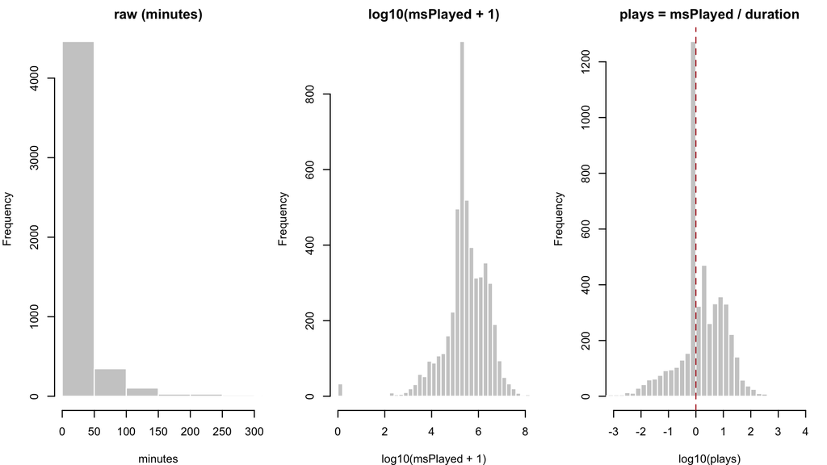

Response on three scales. The raw scale hides its own tail: the mass sits in the first bin and the 40-hour tracks are invisible. On the log scale the skip/non-skip split appears as a separate left mode, and `plays` shows it directly.

```r
par(mfrow = c(1, 3), mar = c(4, 4, 2, 1))
hist(d$msPlayed / 60000, breaks = 60, col = "grey80", border = "white",
     main = "raw (minutes)", xlab = "minutes", xlim = c(0, 300))
hist(d$log_msPlayed, breaks = 40, col = "grey80", border = "white",
     main = "log10(msPlayed + 1)", xlab = "log10(msPlayed + 1)")
hist(log10(d$plays), breaks = 40, col = "grey80", border = "white",
     main = "plays = msPlayed / duration", xlab = "log10(plays)", xlim = c(-3, 4))
abline(v = 0, col = "firebrick", lty = 2)
```

```r
cvars <- c("danceability", "energy", "tempo")
cat("correlation with log10(msPlayed + 1):\n")
```

```
## correlation with log10(msPlayed + 1):
```

```r
print(round(rbind(Pearson  = sapply(cvars, function(v) cor(ca[[v]], ca$log_msPlayed)),
                  Spearman = sapply(cvars, function(v)
                    cor(ca[[v]], ca$log_msPlayed, method = "spearman"))), 3))
```

```
##          danceability energy  tempo
## Pearson         0.007 -0.053 -0.018
## Spearman       -0.011 -0.045 -0.018
```

```r
cat("\ncorrelation among the attributes:\n")
```

```
##
## correlation among the attributes:
```

```r
print(round(cor(ca[, cvars]), 3))
```

```
##              danceability energy tempo
## danceability        1.000  0.278 0.010
## energy              0.278  1.000 0.194
## tempo               0.010  0.194 1.000
```

Two near-zero correlations with the outcome, and weak collinearity among the attributes themselves. Neither fact settles whether the attributes are redundant: redundancy is a question about what a model gains, not about pairwise correlations (Section 4 answers it that way). What the correlations do rule out is the reading that these three variables are a re-encoding of genre — they are largely separate information (Section 7 quantifies how much genre and artist actually recover).

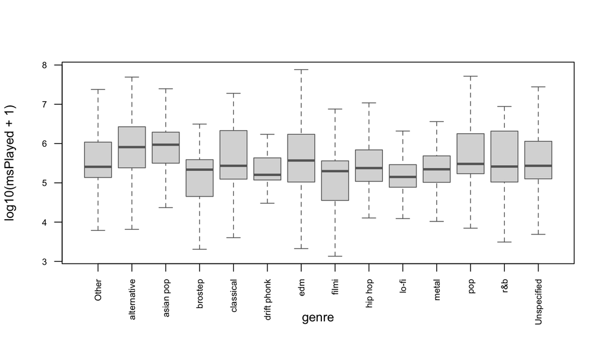

Listening by genre. Differences between genre medians are visible but modest; the spread within any genre dwarfs them.

```r
boxplot(ca$log_msPlayed ~ ca$genre, las = 2, col = "grey85", border = "grey40",
        ylab = "log10(msPlayed + 1)", xlab = "genre", cex.axis = .7, outline = FALSE)
```

```r
cat("share of tracks skipped before one full play, by genre:\n")
```

```
## share of tracks skipped before one full play, by genre:
```

```r
print(round(sort(tapply(ca$plays < 1, ca$genre, mean), decreasing = TRUE), 3))
```

```
##       filmi     brostep       metal drift phonk         edm       lo-fi
##       0.655       0.569       0.520       0.435       0.393       0.390
##       Other         r&b Unspecified     hip hop         pop   classical
##       0.388       0.379       0.375       0.337       0.328       0.315
##   asian pop alternative
##       0.262       0.185
```

# 4. Do the attributes add anything beyond genre and artist?

The model ladder answers exactly one question: **given genre and artist, do danceability, energy and tempo carry additional information about listening?** Everything is on the log scale, on distinct tracks, with audio features present.

```r
f <- list(
  M0 = log_msPlayed ~ 1,
  M1 = log_msPlayed ~ danceability + energy + tempo,
  M2 = log_msPlayed ~ genre,
  M3 = log_msPlayed ~ artistName,
  M4 = log_msPlayed ~ genre + artistName,
  M5 = log_msPlayed ~ danceability + energy + tempo + genre + artistName,
  M6 = log_msPlayed ~ (danceability + energy + tempo) * genre + artistName)
fit <- lapply(f, function(fm) lm(fm, data = ca))
tab <- do.call(rbind, lapply(names(fit), function(nm) {
  m <- fit[[nm]]
  data.frame(model = nm, params = length(coef(m)),
             R2 = summary(m)$r.squared, adjR2 = summary(m)$adj.r.squared,
             AIC = AIC(m), BIC = BIC(m))
}))
print(tab, row.names = FALSE, digits = 4)
```

```
##  model params       R2    adjR2   AIC   BIC
##     M0      1 0.000000 0.000000 12874 12887
##     M1      4 0.003382 0.002754 12864 12896
##     M2     14 0.039019 0.036389 12711 12808
##     M3     52 0.062702 0.052559 12668 13011
##     M4     65 0.083137 0.070652 12589 13016
##     M5     68 0.085695 0.072653 12581 13028
##     M6    107 0.094365 0.073756 12614 13313
```

```r
r2 <- function(m) summary(m)$r.squared
tests <- list(c("M0","M1"), c("M0","M2"), c("M0","M3"), c("M4","M5"),
              c("M5","M6"), c("M2","M4"), c("M3","M4"))
lab <- c("audio alone", "genre alone", "artist alone", "audio | genre+artist",
         "interactions | main effects", "artist | genre", "genre | artist")
bt <- data.frame(comparison = lab,
                 dR2 = c(r2(fit$M1) - r2(fit$M0), r2(fit$M2) - r2(fit$M0),
                         r2(fit$M3) - r2(fit$M0), r2(fit$M5) - r2(fit$M4),
                         r2(fit$M6) - r2(fit$M5), r2(fit$M4) - r2(fit$M2),
                         r2(fit$M4) - r2(fit$M3)))
for (i in seq_along(tests)) {
  a <- anova(fit[[tests[[i]][1]]], fit[[tests[[i]][2]]])
  bt$num_df[i] <- a$Df[2]; bt$den_df[i] <- a$Res.Df[2]
  bt$F[i] <- a$F[2]; bt$p[i] <- a$`Pr(>F)`[2]
}
bt$dR2 <- round(bt$dR2, 4); bt$F <- round(bt$F, 3); bt$p <- signif(bt$p, 3)
print(bt, row.names = FALSE)
```

```
##                   comparison    dR2 num_df den_df      F        p
##                  audio alone 0.0034      3   4761  5.386 1.07e-03
##                  genre alone 0.0390     13   4751 14.839 2.12e-33
##                 artist alone 0.0627     51   4713  6.182 3.34e-38
##         audio | genre+artist 0.0026      3   4697  4.380 4.38e-03
##  interactions | main effects 0.0087     39   4658  1.143 2.50e-01
##               artist | genre 0.0441     51   4700  4.435 3.28e-23
##               genre | artist 0.0204     13   4700  8.058 3.13e-16
```

Three things to read off this table.

1. **Genre and artist both matter, and neither is redundant to the other** by these tests — though BIC, with its heavier penalty, is willing to spend the artist parameters and keep only genre. Each adds significantly over the other (artist given genre p = 3.3e-23; genre given artist p = 3.1e-16). Together they explain 8.3% of the log-variance.
2. **The audio attributes add a small but detectable increment** — $\Delta R^2 = 0.0026$, F(3, 4697) = 4.38, p = 0.0044. That is about 3% of the model’s explained variance — small, but not zero.
3. **Interactions are not supported.** 39 extra parameters buy 0.0087 of R² and fail (p = 0.25); both AIC and BIC penalise the model.

The information criteria do not agree with each other, and that disagreement is part of the honest summary: AIC prefers M5, but **BIC prefers M2 — genre alone**, which drops both the audio block and the 51 artist parameters. BIC is telling us these data do not fund a 68-parameter model, and that is a fair reading; nothing later in this document resolves it. Section 5.2 shows which parts of the result depend on the analyst’s choices and which do not.

## 4.1 Which attribute?

```r
m5 <- fit$M5
X  <- model.matrix(m5); e <- resid(m5); h <- hatvalues(m5)
bread <- solve(crossprod(X))
V_hc3 <- bread %*% crossprod(X * (e / (1 - h))^2, X) %*% bread
V_cl  <- vcov(m5)
out <- do.call(rbind, lapply(c("danceability", "energy", "tempo"), function(v) {
  b <- coef(m5)[v]; se <- sqrt(V_hc3[v, v]); s <- sd(ca[[v]])
  data.frame(attribute = v, b = b, SE_OLS = sqrt(V_cl[v, v]), SE_HC3 = se,
             t = b / se, p = 2 * pt(-abs(b / se), df.residual(m5)),
             pct_per_SD = (10^(b * s) - 1) * 100)
}))
out[, 2:7] <- round(out[, 2:7], 4)
print(out, row.names = FALSE)
```

```
##     attribute       b SE_OLS SE_HC3       t      p pct_per_SD
##  danceability  0.1145 0.0941 0.1044  1.0963 0.2730     4.2459
##        energy -0.1922 0.0650 0.0642 -2.9928 0.0028   -10.2186
##         tempo -0.0007 0.0005 0.0005 -1.5137 0.1302    -4.5855
```

## 4.2 Diagnostics

```r
res <- resid(m5)
aux <- summary(lm(I(res^2) ~ fitted(m5)))
bp  <- aux$r.squared * length(res)
cat("Breusch-Pagan (n x R2 of auxiliary regression) :",
    sprintf("%.1f, p = %.4g", bp, pchisq(bp, 1, lower.tail = FALSE)), "\n")
```

```
## Breusch-Pagan (n x R2 of auxiliary regression) : 14.9, p = 0.0001144
```

```r
cat("residual skew / excess kurtosis                :",
    sprintf("%.2f / %.2f", skew(res), kur(res)), "\n")
```

```
## residual skew / excess kurtosis                : -1.56 / 7.80
```

```r
cat("Shapiro-Wilk (2000-residual sample)            :",
    sprintf("W = %.3f", shapiro.test(sample(res, 2000))$statistic), "\n")
```

```
## Shapiro-Wilk (2000-residual sample)            : W = 0.893
```

```r
cd <- cooks.distance(m5)
cat("Cook's D > 4/n                                 :", sum(cd > 4 / nrow(ca)),
    sprintf("(%.1f%%), max %.3f", 100 * mean(cd > 4 / nrow(ca)), max(cd)), "\n")
```

```
## Cook's D > 4/n                                 : 231 (4.8%), max 0.052
```

```r
Xf <- X[, -1]
vif <- sapply(c("danceability", "energy", "tempo"), function(v)
  1 / (1 - summary(lm(Xf[, v] ~ Xf[, setdiff(colnames(Xf), v)]))$r.squared))
cat("VIF against the full design                    :", round(vif, 2), "\n")
```

```
## VIF against the full design                    : 1.3 1.47 1.07
```

```r
cat("condition number (continuous scaled)           :",
    round(kappa(cbind(scale(Xf[, 1:3]), Xf[, -(1:4)])), 1), "\n")
```

```
## condition number (continuous scaled)           : 24.7
```

```r
# the same diagnostics on the RAW scale, so the comparison in 5.2 is an observed one
raw5 <- lm(msPlayed ~ danceability + energy + tempo + genre + artistName, data = ca)
bres <- summary(lm(I(resid(raw5)^2) ~ fitted(raw5)))$r.squared * nrow(ca)
cat("raw scale: Breusch-Pagan p =", signif(pchisq(bres, 1, lower.tail = FALSE), 3),
    "| residual skew =", sprintf("%.1f", skew(resid(raw5))), "\n")
```

```
## raw scale: Breusch-Pagan p = 1.88e-17 | residual skew = 13.3
```

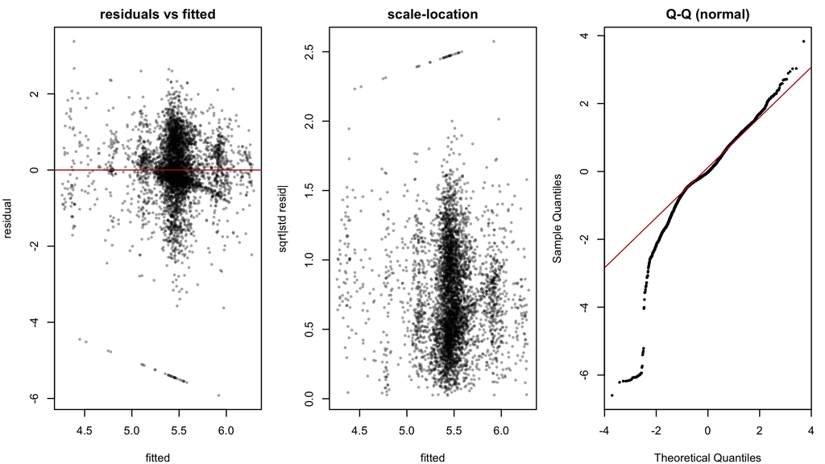

Residual diagnostics. The mild funnel in the scale-location plot is why robust standard errors are reported; the Q-Q deviation reflects the skip/repeat mixture rather than a few influential points.

```r
par(mfrow = c(1, 3), mar = c(4, 4, 2, 1))
plot(fitted(m5), res, pch = 20, col = rgb(0, 0, 0, .25), cex = .6,
     xlab = "fitted", ylab = "residual", main = "residuals vs fitted")
abline(h = 0, col = "firebrick")
plot(fitted(m5), sqrt(abs(scale(res))), pch = 20, col = rgb(0, 0, 0, .25), cex = .6,
     xlab = "fitted", ylab = "sqrt|std resid|", main = "scale-location")
qqnorm(rstandard(m5), pch = 20, cex = .5, main = "Q-Q (normal)")
qqline(rstandard(m5), col = "firebrick")
```

Heteroscedasticity is present and modest, residuals are far from normal, and no observation is influential (largest Cook’s D 0.052, far below 1). The non-normality is a *shape* problem — the response is a crossing of two behaviours — not an outlier problem, which is why the remedy is to report HC3 standard errors and to decompose the response (Section 6) rather than to delete points.

# 5. Out of sample, robustly

## 5.1 One split is an anecdote

The first version reported a single 70/30 split. A 1,400-track test set has an R² standard error of roughly 0.02, which is eight to twenty times the increment under discussion — so one split cannot settle anything. Repeating it 200 times says what the model actually delivers.

```r
set.seed(7); B <- 200
mtx <- sapply(names(f), function(nm) numeric(B))
for (b in 1:B) {
  tr <- sample(nrow(ca), floor(.7 * nrow(ca)))
  for (nm in names(f)) {
    m <- lm(f[[nm]], ca[tr, ]); p <- predict(m, ca[-tr, ])
    ok <- !is.na(p); yt <- ca$log_msPlayed[-tr][ok]
    mtx[, nm][b] <- 1 - sum((yt - p[ok])^2) / sum((yt - mean(ca$log_msPlayed[tr]))^2)
  }
}
cvtab <- data.frame(model = colnames(mtx), test_R2 = colMeans(mtx),
                    sd = apply(mtx, 2, sd),
                    lo = apply(mtx, 2, quantile, .025),
                    hi = apply(mtx, 2, quantile, .975))
cvtab[, 2:5] <- round(cvtab[, 2:5], 4)
print(cvtab, row.names = FALSE)
```

```
##  model test_R2     sd      lo     hi
##     M0  0.0000 0.0000  0.0000 0.0000
##     M1  0.0018 0.0029 -0.0053 0.0057
##     M2  0.0328 0.0085  0.0187 0.0475
##     M3  0.0370 0.0153  0.0037 0.0654
##     M4  0.0505 0.0166  0.0211 0.0788
##     M5  0.0516 0.0165  0.0195 0.0791
##     M6  0.0418 0.0176  0.0098 0.0733
```

```r
dlt <- mtx[, "M5"] - mtx[, "M4"]
cat("\naudio increment out of sample: mean", sprintf("%+.4f", mean(dlt)),
    "95% [", sprintf("%+.4f", quantile(dlt, .025)), ",",
    sprintf("%+.4f", quantile(dlt, .975)), "] positive in",
    sprintf("%.0f%%", 100 * mean(dlt > 0)), "of splits\n")
```

```
##
## audio increment out of sample: mean +0.0011 95% [ -0.0051 , +0.0044 ] positive in 74% of splits
```

```r
# the same model on the raw scale, which is the series the first version reported
raw_r2 <- numeric(B); set.seed(7)
for (b in 1:B) {
  tr <- sample(nrow(ca), floor(.7 * nrow(ca)))
  m  <- lm(msPlayed ~ danceability + energy + tempo + genre + artistName, ca[tr, ])
  pr <- predict(m, ca[-tr, ]); yt <- ca$msPlayed[-tr]
  raw_r2[b] <- 1 - sum((yt - pr)^2) / sum((yt - mean(ca$msPlayed[tr]))^2)
}
cat("same wide model, raw msPlayed scale: mean test R2 =",
    sprintf("%.3f", mean(raw_r2)), "| negative in",
    sprintf("%.0f%%", 100 * mean(raw_r2 < 0)), "of splits\n")
```

```
## same wide model, raw msPlayed scale: mean test R2 = -0.024 | negative in 82% of splits
```

One of these overturns the first version’s conclusion; the other agrees with its caution, but for a completely different reason.

- **The model does generalise.** In at least 97.5% of splits every categorical model has a positive test R² (the 2.5% quantile is above zero for all of them), and the wide model averages 0.052. The earlier claim that the model “does not predict playback time out of sample” was a property of the *raw response scale*, not of the model: the identical specification on `msPlayed` in milliseconds averages -0.024 across the same 200 splits, and is negative in 82% of them, because a handful of enormous values dominate squared error. On a variance-stabilised scale the same model is modest but genuinely predictive.
- **The audio increment does not clearly survive out of sample**: mean +0.0011, interval [-0.0051, +0.0044], positive in 74% of splits. In-sample detectability and out-of-sample usefulness are different claims, and the attributes have more of the first than the second.

## 5.2 Does the conclusion depend on my choices?

A p-value from one specification is worth little if defensible alternatives disagree. The grid below crosses the response scale (log, Box-Cox, raw) with two genre codings and two artist codings and re-tests the audio block in each.

```r
g_as_is <- as.character(ca$genre)
g_other <- { g <- g_as_is; g[g == "Unspecified"] <- "Other"; g }
gv <- list(as_is = g_as_is, unspecified_as_other = g_other)
spec <- data.frame()
for (tn in c("log10", "boxcox", "raw")) {
  yy <- switch(tn,
    log10  = log10(ca$msPlayed + 1),
    boxcox = ((ca$msPlayed + 1)^lam_hat - 1) / lam_hat,
    raw    = ca$msPlayed)
  for (gn in names(gv)) for (ar in c("52-level", "named vs Other")) {
    art <- if (ar == "52-level") factor(ca$artistName)
           else factor(ifelse(as.character(ca$artistName) == "Other", "Other", "named"),
                       levels = c("Other", "named"))
    dd <- data.frame(y = yy, danceability = ca$danceability, energy = ca$energy,
                     tempo = ca$tempo, genre = factor(gv[[gn]]), artist = art)
    r0 <- lm(y ~ genre + artist, dd)
    r1 <- lm(y ~ danceability + energy + tempo + genre + artist, dd)
    spec <- rbind(spec, data.frame(scale = tn, genre = gn, artist = ar,
                                   p = anova(r0, r1)$`Pr(>F)`[2]))
  }
}
spec <- spec[order(spec$p), ]
print(spec, row.names = FALSE, digits = 3)
```

```
##   scale                genre         artist       p
##   log10                as_is       52-level 0.00438
##   log10 unspecified_as_other       52-level 0.00514
##   log10                as_is named vs Other 0.00624
##   log10 unspecified_as_other named vs Other 0.00659
##  boxcox                as_is named vs Other 0.00951
##  boxcox unspecified_as_other named vs Other 0.00999
##  boxcox                as_is       52-level 0.01140
##  boxcox unspecified_as_other       52-level 0.01293
##     raw                as_is named vs Other 0.14477
##     raw unspecified_as_other named vs Other 0.15025
##     raw                as_is       52-level 0.48770
##     raw unspecified_as_other       52-level 0.49365
```

```r
cat("\nrange of the audio-block p-value:", sprintf("%.4f", min(spec$p)), "to",
    sprintf("%.4f", max(spec$p)), "|", sum(spec$p < .05), "of", nrow(spec),
    "specifications below 0.05\n")
```

```
##
## range of the audio-block p-value: 0.0044 to 0.4937 | 8 of 12 specifications below 0.05
```

The choice that moves the headline R² most is **artist pruning**, which the grid above does not touch. The first version kept 178 artist levels; this version keeps 52. Both are defensible, and they are not equivalent.

```r
ca$artist_raw <- trimws(d$artist_full[!d$audio_missing])
thr <- data.frame()
for (k in c(10, 25, 50, 0)) {
  a2 <- if (k == 0) factor(ca$artist_raw) else {
    tt <- table(ca$artist_raw); keep <- names(tt[tt >= k])
    factor(ifelse(ca$artist_raw %in% keep, ca$artist_raw, "Other"))
  }
  dd <- data.frame(y = ca$log_msPlayed, danceability = ca$danceability,
                   energy = ca$energy, tempo = ca$tempo,
                   genre = factor(as.character(ca$genre)), artist = a2)
  r0 <- lm(y ~ genre + artist, dd)
  r1 <- lm(y ~ danceability + energy + tempo + genre + artist, dd)
  thr <- rbind(thr, data.frame(
    artists = if (k == 0) "kept all" else paste0(">=", k, " tracks"),
    levels = nlevels(a2), params = length(coef(r1)),
    R2 = summary(r1)$r.squared, p_audio = anova(r0, r1)[["Pr(>F)"]][2]))
}
thr$R2 <- round(thr$R2, 4); thr$p_audio <- signif(thr$p_audio, 3)
print(thr, row.names = FALSE)
```

```
##      artists levels params     R2 p_audio
##  >=10 tracks     52     68 0.0857 0.00438
##  >=25 tracks     21     37 0.0709 0.00824
##  >=50 tracks      2     18 0.0420 0.00708
##     kept all   2187   2203 0.5689 0.00254
```

```r
# and what the unpruned design costs out of sample (about 8 s per split)
Xa <- model.matrix(~ danceability + energy + tempo + genre + factor(artist_raw),
                   data = ca)
ya <- ca$log_msPlayed
set.seed(5); r2a <- numeric(5)
for (b in 1:5) {
  tr <- sample(nrow(ca), floor(.7 * nrow(ca)))
  cf <- qr.coef(qr(Xa[tr, ]), ya[tr]); cf[is.na(cf)] <- 0
  pr <- as.vector(Xa[-tr, ] %*% cf)
  r2a[b] <- 1 - sum((ya[-tr] - pr)^2) / sum((ya[-tr] - mean(ya[tr]))^2)
}
cat(sprintf("unpruned design, %d splits: mean test R2 %.3f (sd %.3f), negative in %d of %d\n",
            length(r2a), mean(r2a), sd(r2a), sum(r2a < 0), length(r2a)))
```

```
## unpruned design, 5 splits: mean test R2 -0.443 (sd 0.273), negative in 5 of 5
```

R² rises steadily with the number of artist levels — from 0.042 at the strictest pruning to 0.569 when every name is its own dummy — while the audio block stays significant throughout. That upward drift is why the ceiling in Section 7 has to be stated as a property of a threshold rather than of the data: most of the extra R² comes from fitting thousands of artist-specific means to 4,765 tracks, not from new information. Pruning at 10 is the choice this analysis makes, and it is worth being explicit that it is a choice rather than a discovery: it retains enough artists to say something about artist identity, it does not collapse the artist axis to essentially one artist (which is what the >=50 row does), and it is not the row that maximises R². A reader who wants the higher R² has to buy 2,187 artist dummies for 4,765 tracks, and the last line of output above is what that buys out of sample: the unpruned design explains 57% of variance in sample and predicts *worse than the mean* on held-out tracks, in every split tried. The extra R² is memorisation.

## 5.3 Dependence between tracks of the same artist

Artists contribute several tracks each, so their tracks are not independent observations, and ignoring that understates standard errors.

```r
if (have_nlme) {
  m_a <- nlme::lme(log_msPlayed ~ genre + danceability + energy + tempo,
                   random = ~ 1 | artist_raw, data = ca, method = "ML")
  m_0 <- nlme::lme(log_msPlayed ~ genre, random = ~ 1 | artist_raw,
                   data = ca, method = "ML")
  v <- nlme::VarCorr(m_a); bs <- as.numeric(v[1, 2]); rs <- as.numeric(v[2, 2])
  icc <- bs^2 / (bs^2 + rs^2)
  cat(sprintf("between-artist SD %.3f | residual SD %.3f | ICC %.3f\n", bs, rs, icc))
  L <- 2 * (as.numeric(logLik(m_a)) - as.numeric(logLik(m_0)))
  cat(sprintf("audio block inside the random-intercept model: LRT chi2 = %.2f on 3 df, p = %.4g\n",
              L, pchisq(L, 3, lower.tail = FALSE)))
} else {
  icc <- NA; cat("nlme not available - dependence check skipped\n")
}
```

```
## between-artist SD 0.347 | residual SD 0.847 | ICC 0.144
## audio block inside the random-intercept model: LRT chi2 = 13.25 on 3 df, p = 0.004125
```

```r
# clustering is a different problem from heteroscedasticity, and needs its own fix
g  <- droplevels(factor(ca$artist_raw))
Xc <- model.matrix(m5); ec <- resid(m5); bm <- solve(crossprod(Xc))
sG <- rowsum(Xc * ec, g)
Vcl <- bm %*% crossprod(sG) %*% bm
idx <- c("danceability", "energy", "tempo"); b3 <- coef(m5)[idx]
Wcl <- as.numeric(t(b3) %*% solve(Vcl[idx, idx]) %*% b3)
cr1 <- (nlevels(g) / (nlevels(g) - 1)) * ((nrow(ca) - 1) / (nrow(ca) - qr(Xc)$rank))
Wcl <- Wcl * cr1
cat(sprintf("artist-clustered Wald for the audio block: chi2 = %.2f on 3 df, p = %.3g (%d clusters)\n",
            Wcl, pchisq(Wcl, 3, lower.tail = FALSE), nlevels(g)))
```

```
## artist-clustered Wald for the audio block: chi2 = 12.38 on 3 df, p = 0.0062 (2187 clusters)
```

Artist identity accounts for around 14% of the residual variance once genre is in the model, and the audio block survives that reframing as well as the cluster-robust Wald above. The small association is therefore not an artefact of pseudo-replication.

The two corrections answer different questions and are not substitutes: HC3 (Section 4.1) fixes heteroscedasticity and assumes independent observations, while the clustered variance assumes nothing about the variance but allows arbitrary correlation within an artist. Only the second is a valid check on a model whose rows are tracks by the same artists, and it is the one to trust here.

## 5.4 Selection: what excluding the 275 tracks costs

```r
sens <- summary(lm(log10(msPlayed + 1) ~ audio_missing + genre + artistName, data = d))
cat("model on all", nrow(d), "tracks with an indicator for missing audio:\n")
```

```
## model on all 5040 tracks with an indicator for missing audio:
```

```r
cat("  indicator p =", signif(sens$coefficients["audio_missingTRUE", 4], 3),
    "| estimate =", sprintf("%+.3f", sens$coefficients["audio_missingTRUE", 1]),
    sprintf("(%.0f%% less listening)", 100 * (10^sens$coefficients["audio_missingTRUE", 1] - 1)),
    "\n  R2 =", sprintf("%.4f", sens$r.squared), "\n")
```

```
##   indicator p = 0.0411 | estimate = -0.142 (-28% less listening)
##   R2 = 0.0811
```

```r
cat("  R2 of the same model on the audio-complete sample:",
    sprintf("%.4f", summary(fit$M4)$r.squared), "\n")
```

```
##   R2 of the same model on the audio-complete sample: 0.0831
```

That is weak evidence (p = 0.041 on one test, nothing else) that the excluded tracks differ, and the coefficient says in which direction: they were played less. They are therefore not missing at random with respect to the outcome. The exclusion is a real selection effect, it biases the audio-complete sample towards tracks that were listened to, and it is carried into the limitations rather than denied.

# 6. The decomposition that changes the answer

Everything above treats `msPlayed` as one response. It is two: whether a track was skipped, and how much it was played if not. Splitting the question this way resolves the apparent tension of Section 4.1 — that energy is “significant” while the association is tiny.

```r
ca$skip <- as.integer(ca$plays < 1)
lg0 <- glm(skip ~ genre + artistName, data = ca, family = binomial)
lg1 <- glm(skip ~ danceability + energy + tempo + genre + artistName, data = ca, family = binomial)
cat("=== EXTENSIVE margin: P(skipped before one full play) ===\n")
```

```
## === EXTENSIVE margin: P(skipped before one full play) ===
```

```r
print(anova(lg0, lg1, test = "LRT"))
```

```
## Analysis of Deviance Table
##
## Model 1: skip ~ genre + artistName
## Model 2: skip ~ danceability + energy + tempo + genre + artistName
##   Resid. Df Resid. Dev Df Deviance  Pr(>Chi)
## 1      4700     5908.2
## 2      4697     5876.4  3   31.797 5.775e-07 ***
## ---
## Signif. codes:  0 '***' 0.001 '**' 0.01 '*' 0.05 '.' 0.1 ' ' 1
```

```r
bidx <- c("danceability", "energy", "tempo")
Vg <- vcov(lg1); bg <- coef(lg1)[bidx]
W  <- as.numeric(t(bg) %*% solve(Vg[bidx, bidx]) %*% bg)
cat(sprintf("Wald for the audio block: chi2 = %.2f on 3 df, p = %.3g\n",
            W, pchisq(W, 3, lower.tail = FALSE)))
```

```
## Wald for the audio block: chi2 = 31.45 on 3 df, p = 6.83e-07
```

```r
lgt <- summary(lg1)$coefficients[c("danceability", "energy", "tempo"), c(1, 2, 4)]
colnames(lgt) <- c("log_odds", "SE", "p"); lgt <- round(lgt, 4)
cat("\nlogistic coefficients on the skip margin:\n"); print(lgt)
```

```
##
## logistic coefficients on the skip margin:
```

```
##              log_odds     SE      p
## danceability  -0.4020 0.2246 0.0734
## energy         0.8194 0.1553 0.0000
## tempo          0.0010 0.0011 0.3500
```

```r
OR <- exp(coef(lg1)["energy"] * sd(ca$energy))
cat(sprintf("energy odds ratio per SD: %.3f\n", OR))
```

```
## energy odds ratio per SD: 1.221
```

```r
hi <- ca$energy >= quantile(ca$energy, .9)
cat(sprintf("skip rate, top energy decile: %.1f%% | below: %.1f%%\n",
            100 * mean(ca$skip[hi]), 100 * mean(ca$skip[!hi])))
```

```
## skip rate, top energy decile: 47.4% | below: 36.4%
```

```r
sub <- ca[ca$skip == 0, ]
mi0 <- lm(log_msPlayed ~ genre + artistName, data = sub)
mi1 <- lm(log_msPlayed ~ danceability + energy + tempo + genre + artistName, data = sub)
cat("\n=== INTENSIVE margin: listening given at least one full play (n =", nrow(sub), ") ===\n")
```

```
##
## === INTENSIVE margin: listening given at least one full play (n = 2979 ) ===
```

```r
print(anova(mi0, mi1))
```

```
## Analysis of Variance Table
##
## Model 1: log_msPlayed ~ genre + artistName
## Model 2: log_msPlayed ~ danceability + energy + tempo + genre + artistName
##   Res.Df    RSS Df Sum of Sq      F Pr(>F)
## 1   2914 864.12
## 2   2911 862.87  3    1.2538 1.4099 0.2379
```

```r
p_int <- anova(mi0, mi1)[["Pr(>F)"]][2]
Xi <- model.matrix(mi1); ei <- resid(mi1); hi2 <- hatvalues(mi1)
bi <- solve(crossprod(Xi))
Vi <- bi %*% crossprod(Xi * (ei / (1 - hi2))^2, Xi) %*% bi
se_i <- sqrt(Vi["energy", "energy"])
cat(sprintf("energy, HC3: %+.3f (SE %.3f, p = %.3f)\n", coef(mi1)["energy"], se_i,
            2 * pt(-abs(coef(mi1)["energy"] / se_i), df.residual(mi1))))
```

```
## energy, HC3: +0.102 (SE 0.051, p = 0.045)
```

```r
cat(sprintf("energy coefficient: %+.3f (p = %.3f)\n", coef(mi1)["energy"],
            summary(mi1)$coefficients["energy", 4]))
```

```
## energy coefficient: +0.102 (p = 0.040)
```

```r
# same model on all tracks, with an indicator for having reached one full play
m5s <- lm(log_msPlayed ~ danceability + energy + tempo + skip + genre + artistName,
          data = ca)
cat(sprintf("energy without the skip indicator: %+.4f | with it: %+.4f (p = %.2f)\n",
            coef(m5)["energy"], coef(m5s)["energy"],
            summary(m5s)$coefficients["energy", 4]))
```

```
## energy without the skip indicator: -0.1922 | with it: +0.0280 (p = 0.58)
```

```r
sk <- grep("^skip", names(coef(m5s)), value = TRUE)[1]
ps <- summary(m5s)$coefficients[sk, 4]
cat(sprintf("skip indicator itself (%s): %+.4f (p %s)\n", sk, coef(m5s)[[sk]],
            if (ps < 1e-16) "< 1e-16" else sprintf("= %.2g", ps)))
```

```
## skip indicator itself (skip): -1.2233 (p < 1e-16)
```

The contrast is stark, and it is the finding:

- On the **extensive** margin the audio block is clearly detected (p = 7e-07). A one-standard-deviation increase in energy multiplies the odds of falling below one full play by 1.22 — a 22% increase in the odds. In plain terms, tracks in the top energy decile are skipped 47% of the time against 36% below it.
- On the **intensive** margin — among tracks played at least once — the *block* is not significant (p = 0.24), but energy taken on its own is — at least marginally — and the sign is **reversed**: +0.102 (HC3 p = 0.045). Among tracks that were played, higher energy goes with *more* listening.

The pooled -0.19 in Section 4.1 is therefore **not a weighted average of those two slopes**, and it is worth saying so because the arithmetic invites it: the skip margin is a log-odds and the duration margin is a log-time, and -0.19 lies outside the interval spanned by +0.03 and +0.102. The decomposition buys direction and attribution rather than arithmetic: when the model is told whether a track reached one full play, energy’s coefficient moves to +0.028 (p = 0.58, indistinguishable from zero) and the indicator absorbs the association (-1.22).

The two conditional estimates disagree — +0.102 on the played-only subsample, +0.028 when the whole sample is modelled with the indicator — but they agree on the thing that matters: **neither is negative**. What is robustly negative is the association with reaching a full play at all.

Read this as a measurement problem, not a causal one. The response is cumulative listening, so “very short” is bounded below by zero while “long” is bounded by taste, and the same attribute can move the two margins in opposite directions without contradiction. What the data supports is that energy predicts *abandonment before one full play*; it does not support a claim about how long a track is enjoyed once it is being enjoyed.

# 7. What the evidence supports

**On the original question.** Genre and artist are the substantive predictors: together they explain about 8% of the variance in log playback time. The three audio attributes add 0.26 percentage points on top of that, and the increment is statistically detectable (F = 4.38, p = 0.0044). Energy’s coefficient survives an HC3 standard error, and the block survives an artist-clustered Wald (p = 0.0062) and a random intercept for artist. It is **not** equally robust elsewhere: it does not clearly improve out-of-sample prediction (+0.0011 mean test R², positive in 74% of splits), and BIC prefers the model without it — indeed BIC prefers genre alone over any model that includes the artist fixed effects.

**On the two claims this work supersedes.**

- *“The attributes are redundant given genre and artist.”* This is **right about the practical consequence and wrong about the reason**. Taking redundancy to mean what it has to mean operationally — that the attributes add nothing to a model of the outcome — they add 0.26 percentage points, about 3% of the explained variance, and nothing detectable out of sample. Almost all of their potential contribution *is* redundant for this outcome. But they are not *duplicates* of the categoricals: only 18% of danceability, 26% of energy and 4% of tempo are explained by genre and artist, so most of their variance is information the categoricals genuinely do not carry. They are orthogonal to the categoricals **and** uninformative about listening, which is a different thing from being redundant, and it recommends something different: keep the features, stop expecting them to carry a regression.
- *“The model does not predict playback time out of sample.”* **True only on the untransformed scale**, and for a reason that is a property of the response rather than of the model: the identical specification averages -0.024 on `msPlayed` in milliseconds (negative in 82% of 200 splits) and 0.052 on the log scale. Both numbers are in Section 5.1.

**What would still change the answer.** These are the limitations that matter, in rough order of how much they constrain the reading.

- **Only 3 of the 13 audio variables are modelled.** Key, loudness, mode, speechiness, acousticness, instrumentalness, liveness, valence, `duration_ms` and `time_signature` never enter. They were inherited from the first version’s feature selection and not re-derived here, so “the audio attributes are weakly related to listening” is a statement about these three, not about the audio block in general.
- **`duration_ms` is the denominator of the skip definition and is never a covariate.** Long tracks need more accumulated time to reach one full play, so part of what the skip margin measures is track length.
- **The duration-margin estimate conditions on `skip == 0`** — on an outcome of the variable being interpreted. It is a conditional association among played tracks, not a causal duration effect, and a proper hurdle model would be needed before it could be read as one.
- **No multiplicity control.** Roughly a dozen specifications were tested and the headline is p = 0.004; a Bonferroni correction across the twelve specifications would put it at roughly 0.05 — marginal by any reading, which is the right way to treat it.
- **275 tracks (5.5%) have no audio features** and are excluded on evidence that they differ systematically (Section 5.4). The genre taxonomy still puts 49% of the modelling sample in `Other`, which limits what genre can control for.
- **Audio features are algorithmic outputs, not measurements**, so these are not clean structural effects and the direction of any bias is unknown.
- **The response is an aggregate over an unobserved listening history** with no session, device, timestamp or user information, so omitted context cannot be ruled out, and a “skip” here is only an arithmetic fact (`msPlayed < duration`), not evidence that anyone decided anything.

# 8. Reproducing this

```r
cat("R", as.character(getRversion()), "|", R.version$platform, "\n")
```

```
## R 4.6.1 | aarch64-apple-darwin27.0.0
```

```r
cat("packages used: stats, graphics",
    if (have_nlme) "+ nlme", "(nlme optional; the analysis runs without it)\n")
```

```
## packages used: stats, graphics + nlme (nlme optional; the analysis runs without it)
```

```r
# from the repository root:
rmarkdown::render("Enhanced-Spotify-Attribute-Analysis.rmd")
```

The first version of this analysis, which produced the superseded conclusions, is preserved unmodified in `../work/v1/` for comparison.